# Project Python Foundations: FoodHub Data Analysis

### Context

The number of restaurants in New York is increasing day by day. Lots of students and busy professionals rely on those restaurants due to their hectic lifestyles. Online food delivery service is a great option for them. It provides them with good food from their favorite restaurants. A food aggregator company FoodHub offers access to multiple restaurants through a single smartphone app.

The app allows the restaurants to receive a direct online order from a customer. The app assigns a delivery person from the company to pick up the order after it is confirmed by the restaurant. The delivery person then uses the map to reach the restaurant and waits for the food package. Once the food package is handed over to the delivery person, he/she confirms the pick-up in the app and travels to the customer's location to deliver the food. The delivery person confirms the drop-off in the app after delivering the food package to the customer. The customer can rate the order in the app. The food aggregator earns money by collecting a fixed margin of the delivery order from the restaurants.

### Objective

The food aggregator company has stored the data of the different orders made by the registered customers in their online portal. They want to analyze the data to get a fair idea about the demand of different restaurants which will help them in enhancing their customer experience. Suppose you are hired as a Data Scientist in this company and the Data Science team has shared some of the key questions that need to be answered. Perform the data analysis to find answers to these questions that will help the company to improve the business.

### Data Description

The data contains the different data related to a food order. The detailed data dictionary is given below.

### Data Dictionary

- order_id: Unique ID of the order
- customer_id: ID of the customer who ordered the food
- restaurant_name: Name of the restaurant
- cuisine_type: Cuisine ordered by the customer
- cost_of_the_order: Cost of the order
- day_of_the_week: Indicates whether the order is placed on a weekday or weekend (The weekday is from Monday to Friday and the weekend is Saturday and Sunday)
- rating: Rating given by the customer out of 5
- food_preparation_time: Time (in minutes) taken by the restaurant to prepare the food. This is calculated by taking the difference between the timestamps of the restaurant's order confirmation and the delivery person's pick-up confirmation.
- delivery_time: Time (in minutes) taken by the delivery person to deliver the food package. This is calculated by taking the difference between the timestamps of the delivery person's pick-up confirmation and drop-off information

### Let us start by importing the required libraries

```python
# Installing the libraries with the specified version.
!pip install numpy==1.25.2 pandas==1.5.3 matplotlib==3.7.1 seaborn==0.13.1 -q --user
```

[output not shown]

**Note**:

- After running the above cell, kindly restart the runtime (for Google Colab) or notebook kernel (for Jupyter Notebook), and run all cells sequentially from the next cell.
- On executing the above line of code, you might see a warning regarding package dependencies. This error message can be ignored as the above code ensures that all necessary libraries and their dependencies are maintained to successfully execute the code in **this notebook**.

```python
# import libraries for data manipulation
import numpy as np
import pandas as pd

# import libraries for data visualization
import matplotlib.pyplot as plt
import seaborn as sns
```

### Understanding the structure of the data

```python
# uncomment and run the below code snippets if the dataset is present in the Google Drive
from google.colab import drive
drive.mount('/content/drive')
```

[output not shown]

```python
df = pd.read_csv('/content/foodhub_order.csv')
```

```python
display(df.head())
```

|  | order_id | customer_id | restaurant_name | cuisine_type | cost_of_the_order | day_of_the_week | rating | food_preparation_time | delivery_time |
| --- | --- | --- | --- | --- | --- | --- | --- | --- | --- |
| 0 | 1477147 | 337525 | Hangawi | Korean | 30.75 | Weekend | Not given | 25 | 20 |
| 1 | 1477685 | 358141 | Blue Ribbon Sushi Izakaya | Japanese | 12.08 | Weekend | Not given | 25 | 23 |
| 2 | 1477070 | 66393 | Cafe Habana | Mexican | 12.23 | Weekday | 5 | 23 | 28 |
| 3 | 1477334 | 106968 | Blue Ribbon Fried Chicken | American | 29.20 | Weekend | 3 | 25 | 15 |
| 4 | 1478249 | 76942 | Dirty Bird to Go | American | 11.59 | Weekday | 4 | 25 | 24 |

### **Question 1:** How many rows and columns are present in the data? [0.5 mark]

```python
# 1. See the size of data
print(df.shape)

# 2. Check for missing values and data types
df.info()

# 3. Get the statistical summary
df.describe().T
```

```
(1898, 9)
<class 'pandas.core.frame.DataFrame'>
RangeIndex: 1898 entries, 0 to 1897
Data columns (total 9 columns):
 #   Column                 Non-Null Count  Dtype
---  ------                 --------------  -----
 0   order_id               1898 non-null   int64
 1   customer_id            1898 non-null   int64
 2   restaurant_name        1898 non-null   object
 3   cuisine_type           1898 non-null   object
 4   cost_of_the_order      1898 non-null   float64
 5   day_of_the_week        1898 non-null   object
 6   rating                 1898 non-null   object
 7   food_preparation_time  1898 non-null   int64
 8   delivery_time          1898 non-null   int64
dtypes: float64(1), int64(4), object(4)
memory usage: 133.6+ KB
```

|  | count | mean | std | min | 25% | 50% | 75% | max |
| --- | --- | --- | --- | --- | --- | --- | --- | --- |
| order_id | 1898.0 | 1.477496e+06 | 548.049724 | 1476547.00 | 1477021.25 | 1477495.50 | 1.477970e+06 | 1478444.00 |
| customer_id | 1898.0 | 1.711685e+05 | 113698.139743 | 1311.00 | 77787.75 | 128600.00 | 2.705250e+05 | 405334.00 |
| cost_of_the_order | 1898.0 | 1.649885e+01 | 7.483812 | 4.47 | 12.08 | 14.14 | 2.229750e+01 | 35.41 |
| food_preparation_time | 1898.0 | 2.737197e+01 | 4.632481 | 20.00 | 23.00 | 27.00 | 3.100000e+01 | 35.00 |
| delivery_time | 1898.0 | 2.416175e+01 | 4.972637 | 15.00 | 20.00 | 25.00 | 2.800000e+01 | 33.00 |

#### Observations:

1. There are 1,898 total orders recorded in this dataset. Every column has 1898 non-null entries. This means data is very clean and we don't need to fill in missing values.
2. There are 9 columns (information points) for every order.

### **Question 2:** What are the datatypes of the different columns in the dataset? (The info() function can be used) [0.5 mark]

```python
# Display the data types and non-null counts for each column
df.info()
```

```
<class 'pandas.core.frame.DataFrame'>
RangeIndex: 1898 entries, 0 to 1897
Data columns (total 9 columns):
 #   Column                 Non-Null Count  Dtype
---  ------                 --------------  -----
 0   order_id               1898 non-null   int64
 1   customer_id            1898 non-null   int64
 2   restaurant_name        1898 non-null   object
 3   cuisine_type           1898 non-null   object
 4   cost_of_the_order      1898 non-null   float64
 5   day_of_the_week        1898 non-null   object
 6   rating                 1898 non-null   object
 7   food_preparation_time  1898 non-null   int64
 8   delivery_time          1898 non-null   int64
dtypes: float64(1), int64(4), object(4)
memory usage: 133.6+ KB
```

#### **Observations:**

The dataset comprises 1,898 individual orders across 9 unique features, providing a robust and statistically significant sample size for identifying critical trends in customer behavior and operational performance. A primary strength of this data is its total completeness, as every column contains 1,898 non-null values. This lack of missing data ensures high reliability for our statistical conclusions and allows for a seamless transition into analysis without the need for complex data imputation or cleaning.

**Numerical :**

Every column has 1898 non-null entries, which means that data is very clean and we don't need to fill in missing values.

**Categorical (Objects):**

The dataset contains several categorical variables stored as "object" types, including cuisine_type, day_of_the_week, and rating. A critical insight regarding these attributes is that the rating column is classified as an object rather than a numerical type, despite representing a scale from 1 to 5. This classification occurs because many customers opted for a "Not given" response, and since Python interprets these text entries alongside numbers, it treats the entire column as text.

### **Question 3:** Are there any missing values in the data? If yes, treat them using an appropriate method. [1 mark]

```python
# Checking for missing values in the dataset
df.isnull().sum()
```

|  | 0 |
| --- | --- |
| order_id | 0 |
| customer_id | 0 |
| restaurant_name | 0 |
| cuisine_type | 0 |
| cost_of_the_order | 0 |
| day_of_the_week | 0 |
| rating | 0 |
| food_preparation_time | 0 |
| delivery_time | 0 |

**dtype:** int64

#### **Observations:**

The dataset contains 1,898 unique orders across 9 different attributes. The data is high-quality with zero missing values in key numerical fields. However, a significant portion of the ratings are listed as "Not given," which suggests an opportunity to improve customer feedback loops.

### **Question 4:** Check the statistical summary of the data. What is the minimum, average, and maximum time it takes for food to be prepared once an order is placed? [2 marks]

```python
# Statistical summary of all columns (numerical and categorical)
df.describe(include='all').T
```

|  | count | unique | top | freq | mean | std | min | 25% | 50% | 75% | max |
| --- | --- | --- | --- | --- | --- | --- | --- | --- | --- | --- | --- |
| order_id | 1898.0 | NaN | NaN | NaN | 1477495.5 | 548.049724 | 1476547.0 | 1477021.25 | 1477495.5 | 1477969.75 | 1478444.0 |
| customer_id | 1898.0 | NaN | NaN | NaN | 171168.478398 | 113698.139743 | 1311.0 | 77787.75 | 128600.0 | 270525.0 | 405334.0 |
| restaurant_name | 1898 | 178 | Shake Shack | 219 | NaN | NaN | NaN | NaN | NaN | NaN | NaN |
| cuisine_type | 1898 | 14 | American | 584 | NaN | NaN | NaN | NaN | NaN | NaN | NaN |
| cost_of_the_order | 1898.0 | NaN | NaN | NaN | 16.498851 | 7.483812 | 4.47 | 12.08 | 14.14 | 22.2975 | 35.41 |
| day_of_the_week | 1898 | 2 | Weekend | 1351 | NaN | NaN | NaN | NaN | NaN | NaN | NaN |
| rating | 1898 | 4 | Not given | 736 | NaN | NaN | NaN | NaN | NaN | NaN | NaN |
| food_preparation_time | 1898.0 | NaN | NaN | NaN | 27.37197 | 4.632481 | 20.0 | 23.0 | 27.0 | 31.0 | 35.0 |
| delivery_time | 1898.0 | NaN | NaN | NaN | 24.161749 | 4.972637 | 15.0 | 20.0 | 25.0 | 28.0 | 33.0 |

#### **Observations:**

From the statistical summary, the minimum food preparation time is 20 minutes, the average is approximately 27.37 minutes, and the maximum is 35 minutes.

### **Question 5:** How many orders are not rated? [1 mark]

```python
# Count the number of 'Not given' entries in the rating column
not_rated_count = df[df['rating'] == 'Not given'].shape[0]

# Calculate the percentage of unrated orders
total_orders = df.shape[0]
percentage_not_rated = (not_rated_count / total_orders) * 100

print(f"Number of orders that are not rated: {not_rated_count}")
print(f"Percentage of orders not rated: {percentage_not_rated:.2f}%")
```

```
Number of orders that are not rated: 736
Percentage of orders not rated: 38.78%
```

#### **Observations:**

- Number of orders that are not rated: 736
- Percentage of orders not rated: 38.78%
- Improving rating capture should be the top priority to enable data-driven decisions on quality, restaurant performance, and retention.

### Exploratory Data Analysis (EDA)

### **Question 6:** Explore all the variables and provide observations on their distributions. (Generally, histograms, boxplots, countplots, etc. are used for univariate exploration.) [9 marks]

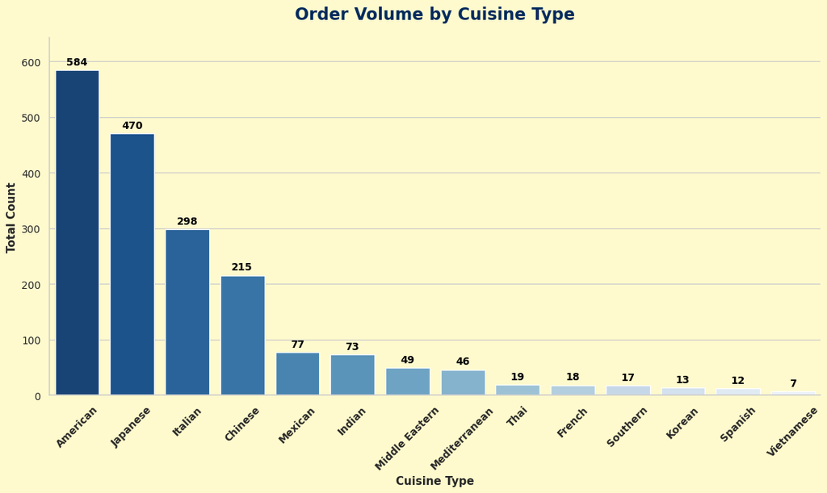

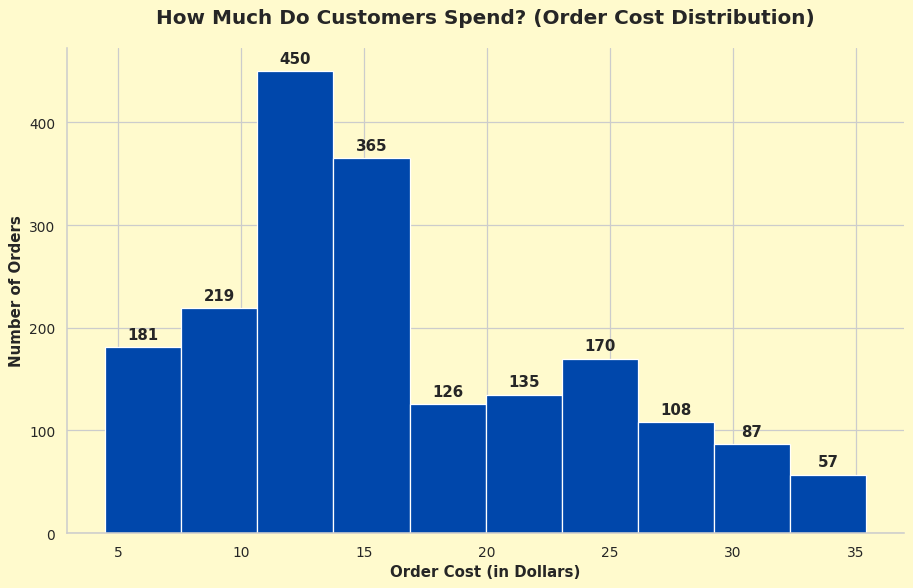

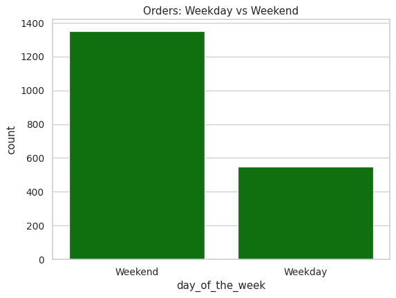

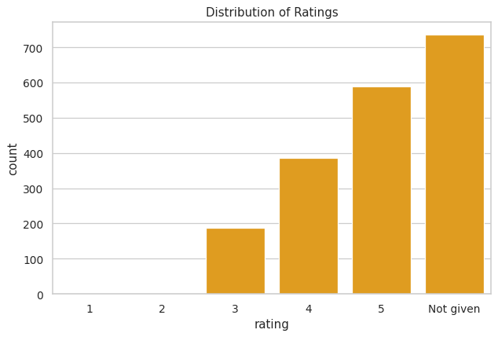

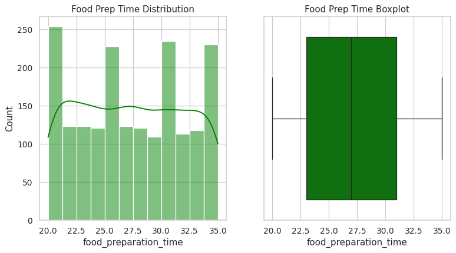

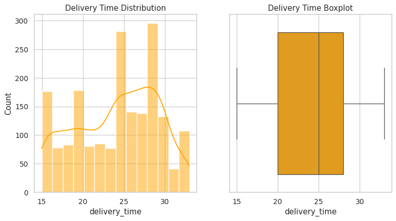

```python
import matplotlib.pyplot as plt
import seaborn as sns

# 1. Prepare data
cuisine_counts = df['cuisine_type'].value_counts()

# 2. Set up the figure and the background color
fig, ax = plt.subplots(figsize=(15, 7))
fig.patch.set_facecolor('#FFFACD')  # Sets the outer border background
ax.set_facecolor('#FFFACD')         # Sets the actual chart background

# 3. Create the Bar Chart with Deep Blue palette
sns.barplot(
    x=cuisine_counts.index,
    y=cuisine_counts.values,
    hue=cuisine_counts.index,
    palette="Blues_r",
    legend=False,
    ax=ax
)

# 4. Add numbers on top of each bar
for p in ax.patches:
    ax.annotate(f'{int(p.get_height())}',
                (p.get_x() + p.get_width() / 2., p.get_height()),
                ha='center', va='center',
                xytext=(0, 9),
                textcoords='offset points',
                fontsize=11, fontweight='bold', color='black')

# 5. Final Styling
plt.title('Order Volume by Cuisine Type', fontsize=18, fontweight='bold', color='#002b5e', pad=20)
plt.xlabel('Cuisine Type', fontsize=12, fontweight='bold')
plt.ylabel('Total Count', fontsize=12, fontweight='bold')
plt.xticks(rotation=45, fontweight='bold')
plt.ylim(0, cuisine_counts.max() * 1.1)

# Removing top and right spines for a cleaner look
ax.spines['top'].set_visible(False)
ax.spines['right'].set_visible(False)

plt.show()


# 1. Set the background color for the whole plot
plt.figure(figsize=(12, 7), facecolor='#FFFACD')
ax = plt.gca()
ax.set_facecolor('#FFFACD')

# 2. Create a simple Histogram
# 'bins=10' creates 10 clear groups of prices
counts, bins, patches = plt.hist(df['cost_of_the_order'],
                                 bins=10,
                                 color='#0047AB',
                                 edgecolor='white')

# 3. Add the exact number on top of each bar
for count, bin_edge in zip(counts, bins):
    if count > 0:
        plt.text(bin_edge + (bins[1]-bins[0])/2, count + 5, int(count),
                 ha='center', va='bottom', fontsize=12, fontweight='bold')

# 4. Clear Labels and Title
plt.title('How Much Do Customers Spend? (Order Cost Distribution)', fontsize=16, fontweight='bold', pad=20)
plt.xlabel('Order Cost (in Dollars)', fontsize=12, fontweight='bold')
plt.ylabel('Number of Orders', fontsize=12, fontweight='bold')

# Remove unnecessary border lines (spines) to keep it clean
sns.despine()

plt.show()


# 3. Day of the Week (Categorical)
plt.figure(figsize=(7, 5))
sns.countplot(data=df, x='day_of_the_week', color='green')
plt.title('Orders: Weekday vs Weekend')
plt.show()

# 4. Rating (Categorical/Ordinal)
plt.figure(figsize=(8, 5))
sns.countplot(data=df, x='rating', order=['1', '2', '3', '4', '5', 'Not given'], color='orange')
plt.title('Distribution of Ratings')
plt.show()

# 5. Food Preparation Time (Numerical)
plt.figure(figsize=(10, 5))
plt.subplot(1, 2, 1)
sns.histplot(df['food_preparation_time'], kde=True, color='green')
plt.title('Food Prep Time Distribution')

plt.subplot(1, 2, 2)
sns.boxplot(x=df['food_preparation_time'], color='green')
plt.title('Food Prep Time Boxplot')
plt.show()

# 6. Delivery Time (Numerical)
plt.figure(figsize=(10, 5))
plt.subplot(1, 2, 1)
sns.histplot(df['delivery_time'], kde=True, color='orange')
plt.title('Delivery Time Distribution')

plt.subplot(1, 2, 2)
sns.boxplot(x=df['delivery_time'], color='orange')
plt.title('Delivery Time Boxplot')
plt.show()
```